# Group 7 Final Project

11/27/2021

## About Datasets

In conducting our final project analysis, we decided to focus on business data, particularly the nuances and relationships that exist between the characteristics of a business/ its owner and the successes/ hardships that must be dealt with. We will begin with a brief introduction to the two datasets that guided our analysis followed by the major components of our methodology and takeaways of our analysis.

## Overview of Dataset I

Each row represents one business’s information

Columns include:

- Info about the owners (age, race, gender, e.t.c.)
- Info about the business (total employees, total payroll, e.t.c.)
- Info about the owner’s relationship to the business (hours spent working, percentage of company owned, e.t.c.)

## Dataset II: Small Business Administration Disaster Loan Data:

The secondary dataset used was from a government source - the Small Business Administration (SBA). Essentially, this is a record of all loans administered to small businesses in the United States and is accompanied by parameters related to the disaster that occured, the size of the loan, the location/ characteristics of the business. In order to ensure compatibility between the two datasets, we only included data based from 2007.

## Overview of Dataset II

Each row represents one incident of a natural disaster in one county

Columns include:

- Multiple numeric codes indicating specific county, natural disaster, and state
- Damaged city’s name
- Total Loss per reported incident

## Analysis of Relationships Between Sector & Businesses

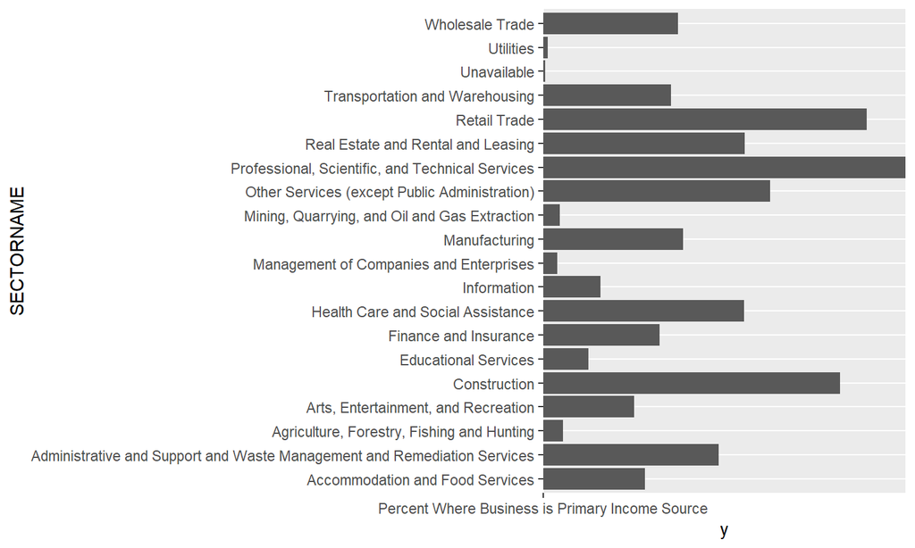

## Relationships Between Education Level & Businesses

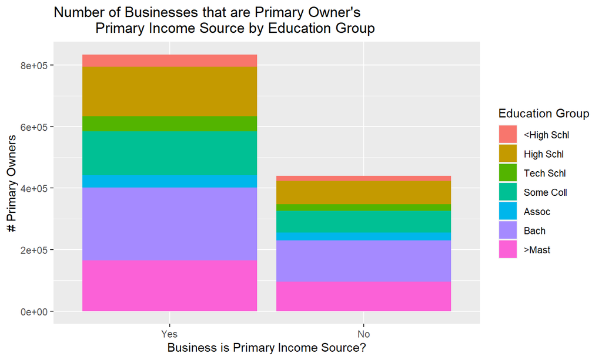

This plot suggests that whether or not a business is someone’s primary income source doesn’t particularly depend on their education level as the two groups appear to have the same general distribution in terms of education group.

## Relationship between Owner’s Education Level & Gender

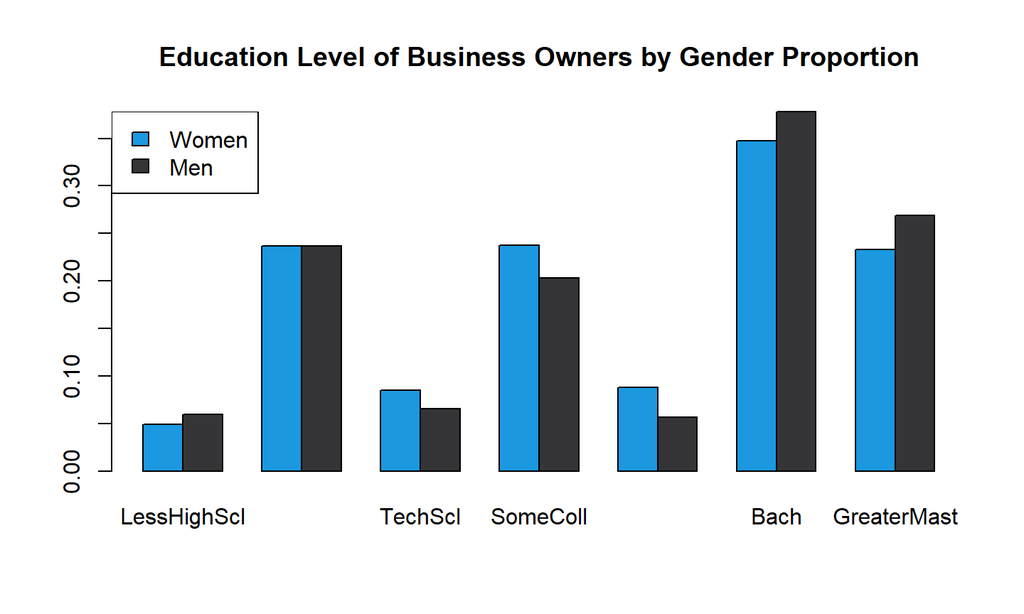

This graph shows the educational level of business owners by gender from dataset I. The proportions shown in this graph reflect the relationship between business owners in a gender from a specific educational level to all business owners of that gender. So for example, approximately 5% of female business owners have less than high school education while approximately 6% of men have the same education level. From this graph, we can see that at lower levels of education, male and female business owners are at similar levels. At the higher education level, female business owners have higher educational rates in tech schools and associates degrees. However, male business owners have higher rates of completion for higher-level education degrees specifically for bachelor and greater than master degrees. And to note, this graph does not account for the ~200,000 female and ~430,000 male business owners who did not fill out this portion of the survey.

## Relationships Between Gender & Owner Hours

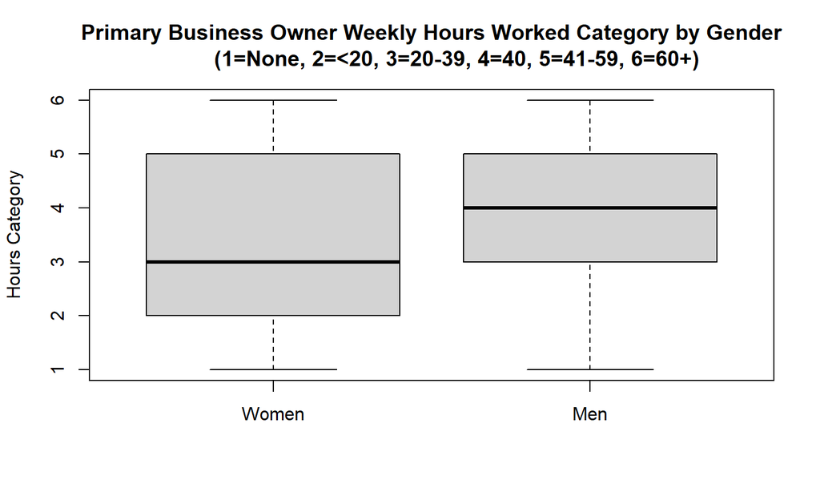

The boxplots show the distribution of the number of hours per week the first owner works, these distributions are then separated based on the first owner’s gender. Based on the boxplots, the male business owners tend to work more hours per week on their business, 40 hours per week, while the women business owners spend an average of 20 to 39 hours per week.

## Relationships Between Owner’s Education Level & Business Payroll

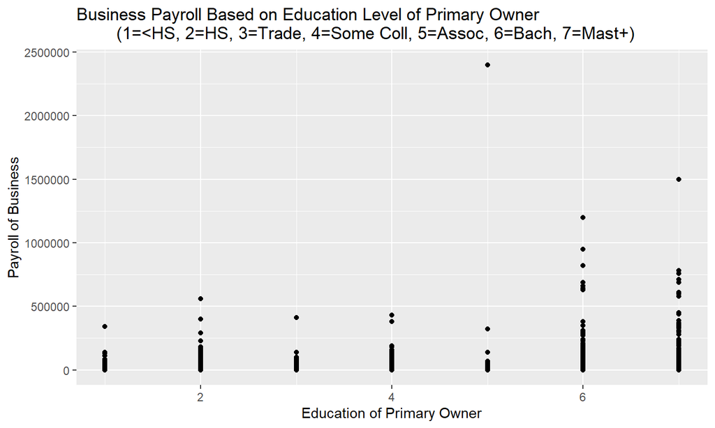

This plot presents a visualization of the education of owner 1, with ratings from less than high school to masters+, on the x-axis against the payroll of the business on the y-axis

## Relationships Between Owner’s Age & Business Number of Employees

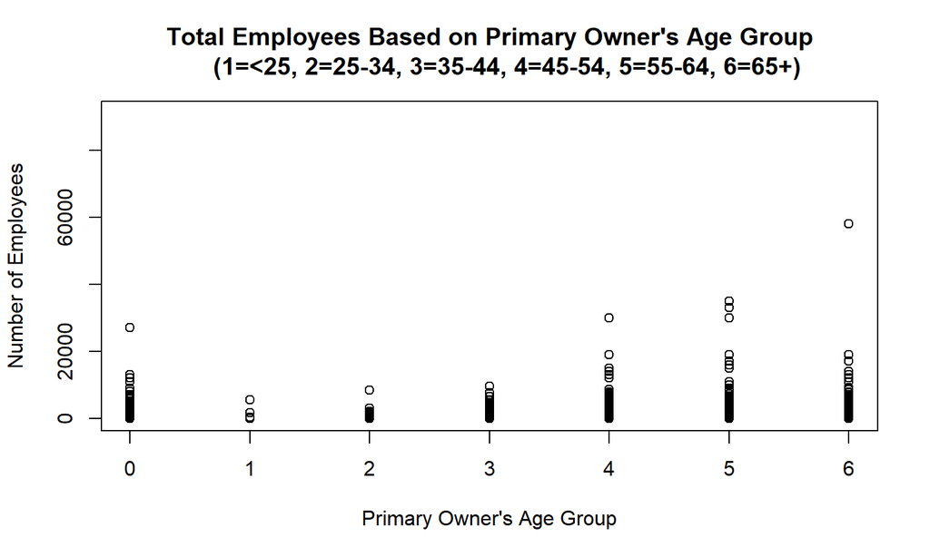

The results of this plot makes sense, since a younger owner results in less employees generally. With older owners, one can find more businesses that have a larger number of employees due to the fact that they had more time to develop their business.